# FINAL NOTEBOOK

**Background:** Adidas is a leading global sportswear brand with a diverse range of products and a vast network of retailers worldwide. In a highly competitive market, it is essential for Adidas to optimize its sales and operational strategies to maximize profitability and customer satisfaction. The company needs a comprehensive understanding of the factors influencing sales performance, including regional differences, product preferences, and the effectiveness of various sales methods. Leveraging data analytics can provide actionable insights to help Adidas improve its marketing strategies, inventory management, and overall business operations.

**Problem Statement:** Adidas is looking to Open a new store and they want to know all the variables they need to consider to get the best bang for their buck. Using Adidas Data combined with geographical data on US cities, we will estimate the best decision for Adidas to present as a business case to investors.

**Objectives:**

- **Discovery:** Load the data
- **Data Prep:** Perform EDA using summary(), head(), glimpse() and visualizations
- **Model Planning:** feature engineering: creating additional features that would be useful
- **Model Building:** perform regression and correlations
- **Communicate Results:** creating visualization to interpret the results
- **Operationalize:** implementing the results and making the regression analysis works

Dataset The Adidas sales database contains the following columns:

- **Retailer:** Represents the business or individual that sells Adidas products directly to consumers.
- **Retailer ID:** A unique identifier assigned to each retailer in the dataset.
- **Invoice Date:** The date when a particular invoice or sales transaction took place.
- **Region:** Refers to a specific geographical area or district where the sales activity or retail operations occur.
- **State:** Represents a specific administrative division or territory within a country.
- **City:** Refers to an urban area or municipality where the sales activity or retail operations are conducted.
- **Gender Type:** Categorization of individuals based on their gender, such as male or female.
- **Product Category:** Represents the classification or grouping of Adidas products.
- **Price per Unit:** The cost or price associated with a single unit of a product.
- **Units Sold:** The quantity or number of units of a particular product sold during a specific sales transaction.
- **Total Sales:** The overall revenue generated from the sales transactions.
- **Operating Profit:** The profit earned by the retailer from its normal business operations.
- **Operating Margin:** A financial metric that indicates the profitability and efficiency of a retailer’s operations.
- **Sales Method:** The approach or channel used by the retailer to sell its products or services.

Steps to Address the Problem Statement Load and Explore the Datasets Data Cleaning and Preparation Merge the Datasets Data Analysis and Visualization Conclusions and Recommendations Let’s go through each step in detail.

1. **Load and Explore the Datasets**

First, we’ll load the datasets and explore their structures.

```r
 #Load necessary libraries
library(tidyverse, warn.conflicts=FALSE)
library(tidymodels,warn.conflicts=FALSE)
```

```r
library(rsample, warn.conflicts=FALSE)
library(yardstick, warn.conflicts=FALSE)
library(rpart, warn.conflicts=FALSE)
library(dplyr, warn.conflicts=FALSE)
library(ggplot2,  warn.conflicts=FALSE)
library(readr, warn.conflicts=FALSE)
library(tidyr, warn.conflicts=FALSE)
library(readxl, warn.conflicts=FALSE)
library(stringr,  warn.conflicts=FALSE)
library(lubridate,  warn.conflicts=FALSE)
library(forecast, warn.conflicts=FALSE)
library(caret, warn.conflicts=FALSE)
library(cluster, warn.conflicts=FALSE)
library(e1071, warn.conflicts=FALSE)
library(naivebayes, warn.conflicts=FALSE)
library(rpart, warn.conflicts=FALSE)
library(corrplot, warn.conflicts=FALSE)
library(rpart.plot, warn.conflicts=FALSE)
library(maps, warn.conflicts=FALSE)
library(geosphere, warn.conflicts=FALSE)
library(sp, warn.conflicts=FALSE)
```

This notebook will randomly split data — initialize the random seed for reproducibility:

```r
set.seed(20240401)
```

```r
 #Load Adidas sales data
adidas_sales_raw <- read_excel("AdidasSalesdata.xlsx")

head(adidas_sales_raw)
```

| Retailer | Retailer ID | Invoice Date | Region | State | City | Gender Type | Product Category | Price per Unit | Units Sold | Total Sales | Operating Profit | Operating Margin | Sales Method |
| --- | --- | --- | --- | --- | --- | --- | --- | --- | --- | --- | --- | --- | --- |
| Foot Locker | 1185732 | 2021-10-26 | Northeast | Pennsylvania | Philadelphia | Men | Apparel | 55 | 125 | 68750 | 24062.5 | 0.35 | Outlet |
| Foot Locker | 1185732 | 2021-10-27 | Northeast | Pennsylvania | Philadelphia | Women | Apparel | 45 | 225 | 101250 | 30375.0 | 0.30 | Outlet |
| Foot Locker | 1185732 | 2021-10-28 | Northeast | Pennsylvania | Philadelphia | Men | Street Footwear | 45 | 475 | 213750 | 117562.5 | 0.55 | Outlet |
| Foot Locker | 1185732 | 2021-10-29 | Northeast | Pennsylvania | Philadelphia | Men | Athletic Footwear | 45 | 125 | 56250 | 19687.5 | 0.35 | Outlet |
| Foot Locker | 1185732 | 2021-10-30 | Northeast | Pennsylvania | Philadelphia | Women | Street Footwear | 35 | 175 | 61250 | 24500.0 | 0.40 | Outlet |
| Foot Locker | 1185732 | 2021-10-31 | Northeast | Pennsylvania | Philadelphia | Women | Athletic Footwear | 40 | 50 | 20000 | 8000.0 | 0.40 | Outlet |

```r
summary(adidas_sales_raw)
```

```
##    Retailer          Retailer ID       Invoice Date
##  Length:9648        Min.   :1128299   Min.   :2020-01-01 00:00:00.00
##  Class :character   1st Qu.:1185732   1st Qu.:2021-02-17 00:00:00.00
##  Mode  :character   Median :1185732   Median :2021-06-04 00:00:00.00
##                     Mean   :1173850   Mean   :2021-05-10 15:20:44.77
##                     3rd Qu.:1185732   3rd Qu.:2021-09-16 00:00:00.00
##                     Max.   :1197831   Max.   :2021-12-31 00:00:00.00
##     Region             State               City           Gender Type
##  Length:9648        Length:9648        Length:9648        Length:9648
##  Class :character   Class :character   Class :character   Class :character
##  Mode  :character   Mode  :character   Mode  :character   Mode  :character
##
##
##
##  Product Category   Price per Unit     Units Sold      Total Sales
##  Length:9648        Min.   :  7.00   Min.   :   0.0   Min.   :     0
##  Class :character   1st Qu.: 35.00   1st Qu.: 106.0   1st Qu.:  4254
##  Mode  :character   Median : 45.00   Median : 176.0   Median :  9576
##                     Mean   : 45.22   Mean   : 256.9   Mean   : 93273
##                     3rd Qu.: 55.00   3rd Qu.: 350.0   3rd Qu.:150000
##                     Max.   :110.00   Max.   :1275.0   Max.   :825000
##  Operating Profit Operating Margin Sales Method
##  Min.   :     0   Min.   :0.100    Length:9648
##  1st Qu.:  1922   1st Qu.:0.350    Class :character
##  Median :  4371   Median :0.410    Mode  :character
##  Mean   : 34425   Mean   :0.423
##  3rd Qu.: 52062   3rd Qu.:0.490
##  Max.   :390000   Max.   :0.800
```

```r
 #Load US cities data
us_cities_raw <- read_csv("uscities.csv", show_col_types = FALSE)
head(us_cities_raw)
```

| city | city_ascii | state_id | state_name | county_fips | county_name | lat | lng | population | density | source | military | incorporated | timezone | ranking | zips | id |
| --- | --- | --- | --- | --- | --- | --- | --- | --- | --- | --- | --- | --- | --- | --- | --- | --- |
| New York | New York | NY | New York | 36081 | Queens | 40.6943 | -73.9249 | 18908608 | 11080.3 | shape | FALSE | TRUE | America/New_York | 1 | 11229 11228 11226 11225 11224 11222 11221 11220 11385 10169 10168 10167 10165 10162 10282 10280 10040 10044 11109 11102 11103 11106 11104 11697 11694 11692 11693 11691 10271 10279 10278 10075 11249 10… | 1840034016 |
| Los Angeles | Los Angeles | CA | California | 06037 | Los Angeles | 34.1141 | -118.4068 | 11922389 | 3184.7 | shape | FALSE | TRUE | America/Los_Angeles | 1 | 91367 90291 90293 90292 91316 91311 90035 90034 90037 90031 90039 90008 90004 90005 90006 90007 90001 90002 90003 91504 91040 90710 90089 91307 91344 91345 91340 91342 91343 90036 90247 91411 91436 91… | 1840020491 |
| Chicago | Chicago | IL | Illinois | 17031 | Cook | 41.8375 | -87.6866 | 8497759 | 4614.5 | shape | FALSE | TRUE | America/Chicago | 1 | 60018 60649 60641 60640 60643 60642 60645 60644 60647 60646 60616 60617 60614 60615 60612 60613 60610 60611 60618 60619 60631 60827 60661 60660 60638 60639 60634 60636 60637 60630 60632 60633 60605 60… | 1840000494 |
| Miami | Miami | FL | Florida | 12086 | Miami-Dade | 25.7840 | -80.2101 | 6080145 | 4758.9 | shape | FALSE | TRUE | America/New_York | 1 | 33128 33129 33125 33126 33127 33149 33144 33145 33142 33139 33138 33137 33136 33135 33134 33133 33132 33131 33130 33150 33101 33109 33111 33151 33192 33195 33222 33231 33233 33238 33255 33299 | 1840015149 |
| Houston | Houston | TX | Texas | 48201 | Harris | 29.7860 | -95.3885 | 5970127 | 1384.0 | shape | FALSE | TRUE | America/Chicago | 1 | 77069 77068 77061 77060 77063 77062 77065 77064 77067 77066 77346 77571 77036 77037 77034 77035 77032 77033 77030 77031 77038 77449 77093 77044 77043 77042 77204 77598 77018 77019 77015 77016 77017 77… | 1840020925 |
| Dallas | Dallas | TX | Texas | 48113 | Dallas | 32.7935 | -96.7667 | 5830932 | 1478.7 | shape | FALSE | TRUE | America/Chicago | 1 | 75098 75287 75230 75231 75236 75237 75235 75254 75251 75252 75253 75043 75032 75227 75238 75232 75233 75234 75089 75088 75087 75247 75244 75249 75248 75051 75166 75210 75211 75212 75214 75215 75216 75… | 1840019440 |

```r
summary(us_cities_raw)
```

```
##      city            city_ascii          state_id          state_name
##  Length:31120       Length:31120       Length:31120       Length:31120
##  Class :character   Class :character   Class :character   Class :character
##  Mode  :character   Mode  :character   Mode  :character   Mode  :character
##
##
##
##  county_fips        county_name             lat             lng
##  Length:31120       Length:31120       Min.   :17.96   Min.   :-176.63
##  Class :character   Class :character   1st Qu.:35.17   1st Qu.: -98.29
##  Mode  :character   Mode  :character   Median :39.33   Median : -90.11
##                                        Mean   :38.62   Mean   : -92.85
##                                        3rd Qu.:41.72   3rd Qu.: -81.83
##                                        Max.   :71.27   Max.   : 174.11
##    population          density           source           military
##  Min.   :       0   Min.   :    0.0   Length:31120       Mode :logical
##  1st Qu.:     272   1st Qu.:   89.3   Class :character   FALSE:31024
##  Median :     957   Median :  247.4   Mode  :character   TRUE :96
##  Mean   :   12884   Mean   :  466.9
##  3rd Qu.:    3768   3rd Qu.:  548.9
##  Max.   :18908608   Max.   :28653.9
##  incorporated      timezone            ranking          zips
##  Mode :logical   Length:31120       Min.   :1.000   Length:31120
##  FALSE:10863     Class :character   1st Qu.:3.000   Class :character
##  TRUE :20257     Mode  :character   Median :3.000   Mode  :character
##                                     Mean   :2.989
##                                     3rd Qu.:3.000
##                                     Max.   :5.000
##        id
##  Min.   :1.630e+09
##  1st Qu.:1.840e+09
##  Median :1.840e+09
##  Mean   :1.838e+09
##  3rd Qu.:1.840e+09
##  Max.   :1.840e+09
```

2. **Data Cleaning and Preparation**

Adidas Sales Data We will check for missing values, correct data types, and filter the data for US cities.

```r
 #Check for missing values

adidas_sales= na.omit(adidas_sales_raw)
glimpse(adidas_sales)
```

```
## Rows: 9,648
## Columns: 14
## $ Retailer           <chr> "Foot Locker", "Foot Locker", "Foot Locker", "Foot …
## $ `Retailer ID`      <dbl> 1185732, 1185732, 1185732, 1185732, 1185732, 118573…
## $ `Invoice Date`     <dttm> 2021-10-26, 2021-10-27, 2021-10-28, 2021-10-29, 20…
## $ Region             <chr> "Northeast", "Northeast", "Northeast", "Northeast",…
## $ State              <chr> "Pennsylvania", "Pennsylvania", "Pennsylvania", "Pe…
## $ City               <chr> "Philadelphia", "Philadelphia", "Philadelphia", "Ph…
## $ `Gender Type`      <chr> "Men", "Women", "Men", "Men", "Women", "Women", "Me…
## $ `Product Category` <chr> "Apparel", "Apparel", "Street Footwear", "Athletic …
## $ `Price per Unit`   <dbl> 55, 45, 45, 45, 35, 40, 55, 45, 50, 50, 40, 45, 60,…
## $ `Units Sold`       <dbl> 125, 225, 475, 125, 175, 50, 125, 225, 445, 150, 17…
## $ `Total Sales`      <dbl> 68750, 101250, 213750, 56250, 61250, 20000, 68750, …
## $ `Operating Profit` <dbl> 24062.5, 30375.0, 117562.5, 19687.5, 24500.0, 8000.…
## $ `Operating Margin` <dbl> 0.35, 0.30, 0.55, 0.35, 0.40, 0.40, 0.35, 0.30, 0.5…
## $ `Sales Method`     <chr> "Outlet", "Outlet", "Outlet", "Outlet", "Outlet", "…
```

US Cities Data We will ensure the data has the necessary columns for merging and clean it if needed.

```r
us_cities= na.omit(us_cities_raw)
glimpse(us_cities)
```

```
## Rows: 31,118
## Columns: 17
## $ city         <chr> "New York", "Los Angeles", "Chicago", "Miami", "Houston",…
## $ city_ascii   <chr> "New York", "Los Angeles", "Chicago", "Miami", "Houston",…
## $ state_id     <chr> "NY", "CA", "IL", "FL", "TX", "TX", "PA", "GA", "DC", "MA…
## $ state_name   <chr> "New York", "California", "Illinois", "Florida", "Texas",…
## $ county_fips  <chr> "36081", "06037", "17031", "12086", "48201", "48113", "42…
## $ county_name  <chr> "Queens", "Los Angeles", "Cook", "Miami-Dade", "Harris", …
## $ lat          <dbl> 40.6943, 34.1141, 41.8375, 25.7840, 29.7860, 32.7935, 40.…
## $ lng          <dbl> -73.9249, -118.4068, -87.6866, -80.2101, -95.3885, -96.76…
## $ population   <dbl> 18908608, 11922389, 8497759, 6080145, 5970127, 5830932, 5…
## $ density      <dbl> 11080.3, 3184.7, 4614.5, 4758.9, 1384.0, 1478.7, 4578.4, …
## $ source       <chr> "shape", "shape", "shape", "shape", "shape", "shape", "sh…
## $ military     <lgl> FALSE, FALSE, FALSE, FALSE, FALSE, FALSE, FALSE, FALSE, F…
## $ incorporated <lgl> TRUE, TRUE, TRUE, TRUE, TRUE, TRUE, TRUE, TRUE, TRUE, TRU…
## $ timezone     <chr> "America/New_York", "America/Los_Angeles", "America/Chica…
## $ ranking      <dbl> 1, 1, 1, 1, 1, 1, 1, 1, 1, 1, 1, 1, 1, 1, 1, 1, 1, 1, 1, …
## $ zips         <chr> "11229 11228 11226 11225 11224 11222 11221 11220 11385 10…
## $ id           <dbl> 1840034016, 1840020491, 1840000494, 1840015149, 184002092…
```

```r
# Renaming
adidas_sales  <- adidas_sales  %>% rename("ID" = `Retailer ID`)
adidas_sales <- adidas_sales %>% rename("Gender" = `Gender Type`)
adidas_sales  <- adidas_sales %>% rename("Category" = `Product Category`)
adidas_sales <- adidas_sales  %>% rename("SalesMethod" =  `Sales Method`)
adidas_sales  <- adidas_sales  %>% rename("PricePerUnit" =  `Price per Unit`)
adidas_sales  <- adidas_sales  %>% rename("UnitsSold" =  `Units Sold`)
adidas_sales  <- adidas_sales %>% rename("TotalSales" =  `Total Sales`)
adidas_sales  <- adidas_sales  %>% rename("Profit" =  `Operating Profit`)
adidas_sales <- adidas_sales %>% rename("Margin" =  `Operating Margin`)
adidas_sales  <- adidas_sales  %>% rename("Date" = `Invoice Date`)
```

**Creating Outcome Variable**

```r
adidas_sales = adidas_sales%>%
  mutate(Outcome = as.factor(if_else(SalesMethod == "Online", "In-store", "Outlet")))

head(adidas_sales)
```

| Retailer | ID | Date | Region | State | City | Gender | Category | PricePerUnit | UnitsSold | TotalSales | Profit | Margin | SalesMethod | Outcome |
| --- | --- | --- | --- | --- | --- | --- | --- | --- | --- | --- | --- | --- | --- | --- |
| Foot Locker | 1185732 | 2021-10-26 | Northeast | Pennsylvania | Philadelphia | Men | Apparel | 55 | 125 | 68750 | 24062.5 | 0.35 | Outlet | Outlet |
| Foot Locker | 1185732 | 2021-10-27 | Northeast | Pennsylvania | Philadelphia | Women | Apparel | 45 | 225 | 101250 | 30375.0 | 0.30 | Outlet | Outlet |
| Foot Locker | 1185732 | 2021-10-28 | Northeast | Pennsylvania | Philadelphia | Men | Street Footwear | 45 | 475 | 213750 | 117562.5 | 0.55 | Outlet | Outlet |
| Foot Locker | 1185732 | 2021-10-29 | Northeast | Pennsylvania | Philadelphia | Men | Athletic Footwear | 45 | 125 | 56250 | 19687.5 | 0.35 | Outlet | Outlet |
| Foot Locker | 1185732 | 2021-10-30 | Northeast | Pennsylvania | Philadelphia | Women | Street Footwear | 35 | 175 | 61250 | 24500.0 | 0.40 | Outlet | Outlet |
| Foot Locker | 1185732 | 2021-10-31 | Northeast | Pennsylvania | Philadelphia | Women | Athletic Footwear | 40 | 50 | 20000 | 8000.0 | 0.40 | Outlet | Outlet |

```r
 #Merge the datasets
merged_data <- adidas_sales %>%
  left_join(us_cities, by = c( "State" = "state_name"))
 #Check the merged dataset
head(merged_data)
```

| Retailer | ID | Date | Region | State | City | Gender | Category | PricePerUnit | UnitsSold | TotalSales | Profit | Margin | SalesMethod | Outcome | city | city_ascii | state_id | county_fips | county_name | lat | lng | population | density | source | military | incorporated | timezone | ranking | zips | … |
| --- | --- | --- | --- | --- | --- | --- | --- | --- | --- | --- | --- | --- | --- | --- | --- | --- | --- | --- | --- | --- | --- | --- | --- | --- | --- | --- | --- | --- | --- | --- |
| Foot Locker | 1185732 | 2021-10-26 | Northeast | Pennsylvania | Philadelphia | Men | Apparel | 55 | 125 | 68750 | 24062.5 | 0.35 | Outlet | Outlet | Philadelphia | Philadelphia | PA | 42101 | Philadelphia | 40.0077 | -75.1339 | 5683533 | 4578.4 | shape | FALSE | TRUE | America/New_York | 1 | 19154 19151 19150 19153 19152 19102 19103 19106 19107 19104 19108 19109 19128 19129 19120 19121 19122 19123 19124 19125 19126 19127 19112 19111 19115 19114 19116 19119 19118 19148 19149 19146 19147 19… | … |
| Foot Locker | 1185732 | 2021-10-26 | Northeast | Pennsylvania | Philadelphia | Men | Apparel | 55 | 125 | 68750 | 24062.5 | 0.35 | Outlet | Outlet | Pittsburgh | Pittsburgh | PA | 42003 | Allegheny | 40.4397 | -79.9763 | 1749091 | 2118.5 | shape | FALSE | TRUE | America/New_York | 1 | 15282 15216 15217 15214 15212 15213 15210 15211 15218 15219 15290 15232 15260 15233 15205 15204 15207 15206 15201 15203 15208 15234 15222 15221 15220 15226 15224 15120 15230 15240 15250 15251 15252 15… | … |
| Foot Locker | 1185732 | 2021-10-26 | Northeast | Pennsylvania | Philadelphia | Men | Apparel | 55 | 125 | 68750 | 24062.5 | 0.35 | Outlet | Outlet | Allentown | Allentown | PA | 42077 | Lehigh | 40.5961 | -75.4756 | 627863 | 2754.2 | shape | FALSE | TRUE | America/New_York | 2 | 18104 18101 18103 18102 18109 18001 18105 | … |
| Foot Locker | 1185732 | 2021-10-26 | Northeast | Pennsylvania | Philadelphia | Men | Apparel | 55 | 125 | 68750 | 24062.5 | 0.35 | Outlet | Outlet | Harrisburg | Harrisburg | PA | 42043 | Dauphin | 40.2752 | -76.8843 | 498329 | 2380.4 | shape | FALSE | TRUE | America/New_York | 2 | 17101 17102 17103 17104 17120 17110 17105 17108 17121 17122 17123 17124 17125 17126 17127 17128 17129 17130 | … |
| Foot Locker | 1185732 | 2021-10-26 | Northeast | Pennsylvania | Philadelphia | Men | Apparel | 55 | 125 | 68750 | 24062.5 | 0.35 | Outlet | Outlet | Lancaster | Lancaster | PA | 42071 | Lancaster | 40.0420 | -76.3012 | 402476 | 3096.9 | shape | FALSE | TRUE | America/New_York | 2 | 17603 17602 17601 17608 17622 17699 | … |
| Foot Locker | 1185732 | 2021-10-26 | Northeast | Pennsylvania | Philadelphia | Men | Apparel | 55 | 125 | 68750 | 24062.5 | 0.35 | Outlet | Outlet | Scranton | Scranton | PA | 42069 | Lackawanna | 41.4044 | -75.6649 | 366334 | 1161.3 | shape | FALSE | TRUE | America/New_York | 2 | 18504 18509 18508 18510 18503 18505 18507 18515 18540 | … |

Drop NA values

```r
merged_data= na.omit(merged_data)
glimpse(merged_data)
```

```
## Rows: 6,501,528
## Columns: 31
## $ Retailer     <chr> "Foot Locker", "Foot Locker", "Foot Locker", "Foot Locker…
## $ ID           <dbl> 1185732, 1185732, 1185732, 1185732, 1185732, 1185732, 118…
## $ Date         <dttm> 2021-10-26, 2021-10-26, 2021-10-26, 2021-10-26, 2021-10-…
## $ Region       <chr> "Northeast", "Northeast", "Northeast", "Northeast", "Nort…
## $ State        <chr> "Pennsylvania", "Pennsylvania", "Pennsylvania", "Pennsylv…
## $ City         <chr> "Philadelphia", "Philadelphia", "Philadelphia", "Philadel…
## $ Gender       <chr> "Men", "Men", "Men", "Men", "Men", "Men", "Men", "Men", "…
## $ Category     <chr> "Apparel", "Apparel", "Apparel", "Apparel", "Apparel", "A…
## $ PricePerUnit <dbl> 55, 55, 55, 55, 55, 55, 55, 55, 55, 55, 55, 55, 55, 55, 5…
## $ UnitsSold    <dbl> 125, 125, 125, 125, 125, 125, 125, 125, 125, 125, 125, 12…
## $ TotalSales   <dbl> 68750, 68750, 68750, 68750, 68750, 68750, 68750, 68750, 6…
## $ Profit       <dbl> 24062.5, 24062.5, 24062.5, 24062.5, 24062.5, 24062.5, 240…
## $ Margin       <dbl> 0.35, 0.35, 0.35, 0.35, 0.35, 0.35, 0.35, 0.35, 0.35, 0.3…
```

[output cut: 18 more lines]

[figure not shown]

```r
 #Summarize total sales by state
total_sales_by_state <- merged_data %>%
  group_by(State) %>%
  summarize(total_sales = "Total Sales")
total_sales_by_state= na.omit(total_sales_by_state)

# Plot total sales by State
ggplot(total_sales_by_state, aes(x = State, y = total_sales)) +
  geom_bar(stat = "identity", fill = "steelblue") +  coord_flip() +
  labs(title = "Total Sales by State", x = "State", y = "Total Sales")
```

Train-Test Split

```r
 #Split the data into training and testing sets


data_split <- initial_split(merged_data, prop = 0.75)
train_data <- training(data_split)
test_data <- testing(data_split)
```

5. **Distribution of Outcomes**

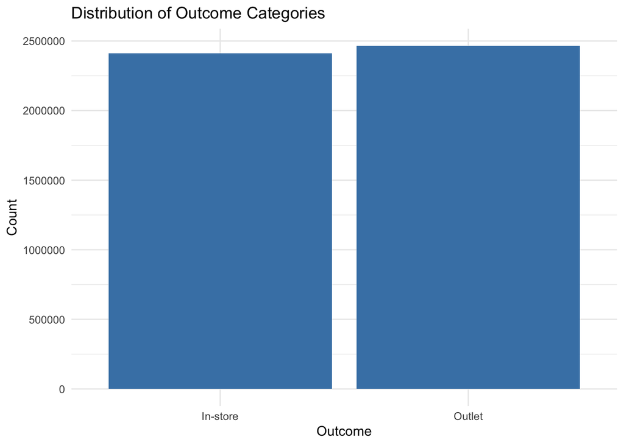

```r
#Bar plot of Outcome
ggplot(train_data, aes(x = Outcome)) +
  geom_bar(fill = "steelblue") +
  theme_minimal() +
  labs(title = "Distribution of Outcome Categories", x = "Outcome", y = "Count")
```

```r
nb.cols = c("lat", "lng", "population", "Profit", "Outcome", "incorporated")
```

Train Naive Bayes Model

```r
nb.train = train_data %>%
  select(Outcome, any_of(nb.cols)) %>%
  mutate(across(everything(), as.factor)) %>%
  as.data.frame()
glimpse(nb.train)
```

```
## Rows: 4,876,146
## Columns: 6
## $ Outcome      <fct> In-store, In-store, Outlet, Outlet, In-store, In-store, O…
## $ lat          <fct> 31.3398, 40.3017, 33.0508, 43.3101, 38.9549, 40.3969, 39.…
## $ lng          <fct> -92.1389, -121.2339, -84.3082, -88.5192, -76.7406, -90.15…
## $ population   <fct> 1083, 2271, 239, 605, 57922, 1938, 1696, 6048, 1845, 288,…
## $ Profit       <fct> 2444, 5416.2, 2940.52, 5625, 196, 3045.12, 81812.5, 4352,…
## $ incorporated <fct> FALSE, FALSE, TRUE, TRUE, TRUE, TRUE, FALSE, FALSE, TRUE,…
```

```r
 #Predict on test data
mod.nb = naive_bayes(Outcome~  incorporated+ lat + lng + population+ Profit, nb.train)
summary(mod.nb)
```

```
##
## ================================= Naive Bayes ==================================
##
## - Call: naive_bayes.formula(formula = Outcome ~ incorporated + lat +      lng + population + Profit, data = nb.train)
## - Laplace: 0
## - Classes: 2
## - Samples: 4876146
## - Features: 5
## - Conditional distributions:
##     - Bernoulli: 1
##     - Categorical: 4
## - Prior probabilities:
##     - In-store: 0.4944
##     - Outlet: 0.5056
##
## --------------------------------------------------------------------------------
```

```r
nb.test = test_data %>%
  select(Outcome, any_of(nb.cols)) %>%
  mutate(across(everything(), as.factor)) %>%
  as.data.frame()
glimpse(nb.test)
```

```
## Rows: 1,625,382
## Columns: 6
## $ Outcome      <fct> Outlet, Outlet, Outlet, Outlet, Outlet, Outlet, Outlet, O…
## $ lat          <fct> 40.4397, 40.5961, 40.042, 41.2469, 40.3238, 39.9495, 40.0…
## $ lng          <fct> -79.9763, -75.4756, -76.3012, -75.876, -80.0364, -75.3038…
## $ population   <fct> 1749091, 627863, 402476, 44123, 33275, 29231, 24423, 2335…
## $ Profit       <fct> 24062.5, 24062.5, 24062.5, 24062.5, 24062.5, 24062.5, 240…
## $ incorporated <fct> TRUE, TRUE, TRUE, TRUE, TRUE, FALSE, FALSE, TRUE, FALSE, …
```

```r
nb.test$Prediction = predict(mod.nb, nb.test %>% select(-Outcome))
glimpse(nb.test)
```

```
## Rows: 1,625,382
## Columns: 7
## $ Outcome      <fct> Outlet, Outlet, Outlet, Outlet, Outlet, Outlet, Outlet, O…
## $ lat          <fct> 40.4397, 40.5961, 40.042, 41.2469, 40.3238, 39.9495, 40.0…
## $ lng          <fct> -79.9763, -75.4756, -76.3012, -75.876, -80.0364, -75.3038…
## $ population   <fct> 1749091, 627863, 402476, 44123, 33275, 29231, 24423, 2335…
## $ Profit       <fct> 24062.5, 24062.5, 24062.5, 24062.5, 24062.5, 24062.5, 240…
## $ incorporated <fct> TRUE, TRUE, TRUE, TRUE, TRUE, FALSE, FALSE, TRUE, FALSE, …
## $ Prediction   <fct> Outlet, Outlet, Outlet, Outlet, Outlet, Outlet, Outlet, O…
```

```r
 #Calculate accuracy, sensitivity, specificity
accuracy <- mean(nb.test$Outcome == nb.test$Prediction)
sensitivity <- sum(nb.test$Outcome == "In-store" & nb.test$Prediction  == "In-store") / sum(nb.test$Outcome == "In-store")
specificity <- sum(nb.test$Outcome == "Outlet" & nb.test$Prediction == "Outlet") / sum(nb.test$Outcome == "Outlet")
precision = sum(nb.test$Outcome == nb.test$Prediction & nb.test$Prediction == "In-store") / sum(nb.test$Prediction == "In-store")

 #Combine results into a data frame
nb.results <- data.frame(
  Model = "Naive Bayes",
  accuracy = accuracy,
  sensitivity = sensitivity,
  specificity = specificity,
  precision = precision
)

 #Display the results
summary(nb.results)
```

```
##     Model              accuracy       sensitivity      specificity
##  Length:1           Min.   :0.4655   Min.   :0.1658   Min.   :0.7588
##  Class :character   1st Qu.:0.4655   1st Qu.:0.1658   1st Qu.:0.7588
##  Mode  :character   Median :0.4655   Median :0.1658   Median :0.7588
##                     Mean   :0.4655   Mean   :0.1658   Mean   :0.7588
##                     3rd Qu.:0.4655   3rd Qu.:0.1658   3rd Qu.:0.7588
##                     Max.   :0.4655   Max.   :0.1658   Max.   :0.7588
##    precision
##  Min.   :0.4021
##  1st Qu.:0.4021
##  Median :0.4021
##  Mean   :0.4021
##  3rd Qu.:0.4021
##  Max.   :0.4021
```

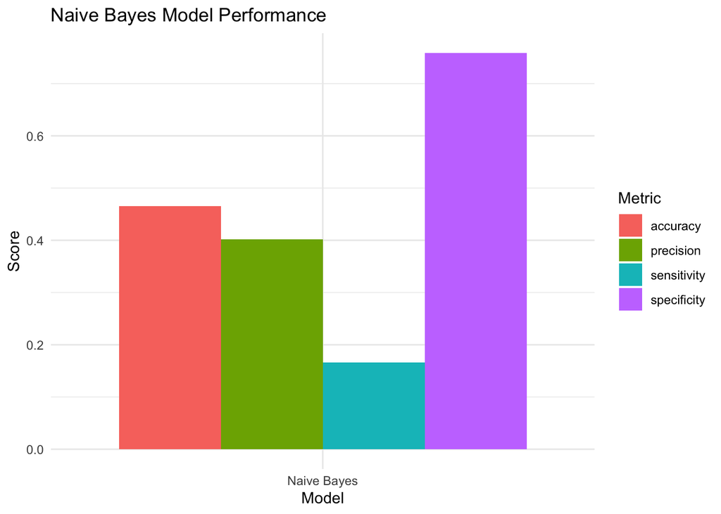

```r
 #Remove empty columns
nb.results <- nb.results %>%
  select(-contains("estimator"),-contains("metric"))
 #Plot
nb.results %>%
  pivot_longer(cols = -Model) %>%
  ggplot(aes(x = Model, y = value, fill = name)) +
  geom_bar(stat = "identity", position = "dodge") +
  labs(title = "Naive Bayes Model Performance",
       y = "Score", fill = "Metric") +
  theme_minimal()
```

7. Decision Tree

```r
tree_model <- rpart(Outcome~  incorporated+ lat + lng + population+ Profit, train_data)
```

```r
dt.test = test_data %>%
  mutate(Prediction = predict(tree_model, test_data, type="class"))
glimpse(dt.test)
```

```
## Rows: 1,625,382
## Columns: 32
## $ Retailer     <chr> "Foot Locker", "Foot Locker", "Foot Locker", "Foot Locker…
## $ ID           <dbl> 1185732, 1185732, 1185732, 1185732, 1185732, 1185732, 118…
## $ Date         <dttm> 2021-10-26, 2021-10-26, 2021-10-26, 2021-10-26, 2021-10-…
## $ Region       <chr> "Northeast", "Northeast", "Northeast", "Northeast", "Nort…
## $ State        <chr> "Pennsylvania", "Pennsylvania", "Pennsylvania", "Pennsylv…
## $ City         <chr> "Philadelphia", "Philadelphia", "Philadelphia", "Philadel…
## $ Gender       <chr> "Men", "Men", "Men", "Men", "Men", "Men", "Men", "Men", "…
## $ Category     <chr> "Apparel", "Apparel", "Apparel", "Apparel", "Apparel", "A…
## $ PricePerUnit <dbl> 55, 55, 55, 55, 55, 55, 55, 55, 55, 55, 55, 55, 55, 55, 5…
## $ UnitsSold    <dbl> 125, 125, 125, 125, 125, 125, 125, 125, 125, 125, 125, 12…
## $ TotalSales   <dbl> 68750, 68750, 68750, 68750, 68750, 68750, 68750, 68750, 6…
## $ Profit       <dbl> 24062.5, 24062.5, 24062.5, 24062.5, 24062.5, 24062.5, 240…
## $ Margin       <dbl> 0.35, 0.35, 0.35, 0.35, 0.35, 0.35, 0.35, 0.35, 0.35, 0.3…
```

[output cut: 19 more lines]

```r
 #Calculate accuracy, sensitivity, specificity
accuracy <- mean(dt.test$Outcome == dt.test$Prediction)
sensitivity <- sum(dt.test$Outcome == "In-store" & dt.test$Prediction  == "In-store") / sum(dt.test$Outcome == "In-store")
specificity <- sum(dt.test$Outcome == "Outlet" & dt.test$Prediction == "Outlet") / sum(dt.test$Outcome == "Outlet")
precision = sum(dt.test$Outcome == dt.test$Prediction & dt.test$Prediction == "In-store") / sum(dt.test$Prediction == "In-store")

 #Combine results into a data frame
dt.results <- data.frame(
  Model = "Decison",
  accuracy = accuracy,
  sensitivity = sensitivity,
  specificity = specificity,
  precision = precision
)

 #Display the results
summary(dt.results)
```

```
##     Model              accuracy      sensitivity      specificity
##  Length:1           Min.   :0.747   Min.   :0.7622   Min.   :0.7322
##  Class :character   1st Qu.:0.747   1st Qu.:0.7622   1st Qu.:0.7322
##  Mode  :character   Median :0.747   Median :0.7622   Median :0.7322
##                     Mean   :0.747   Mean   :0.7622   Mean   :0.7322
##                     3rd Qu.:0.747   3rd Qu.:0.7622   3rd Qu.:0.7322
##                     Max.   :0.747   Max.   :0.7622   Max.   :0.7322
##    precision
##  Min.   :0.7357
##  1st Qu.:0.7357
##  Median :0.7357
##  Mean   :0.7357
##  3rd Qu.:0.7357
##  Max.   :0.7357
```

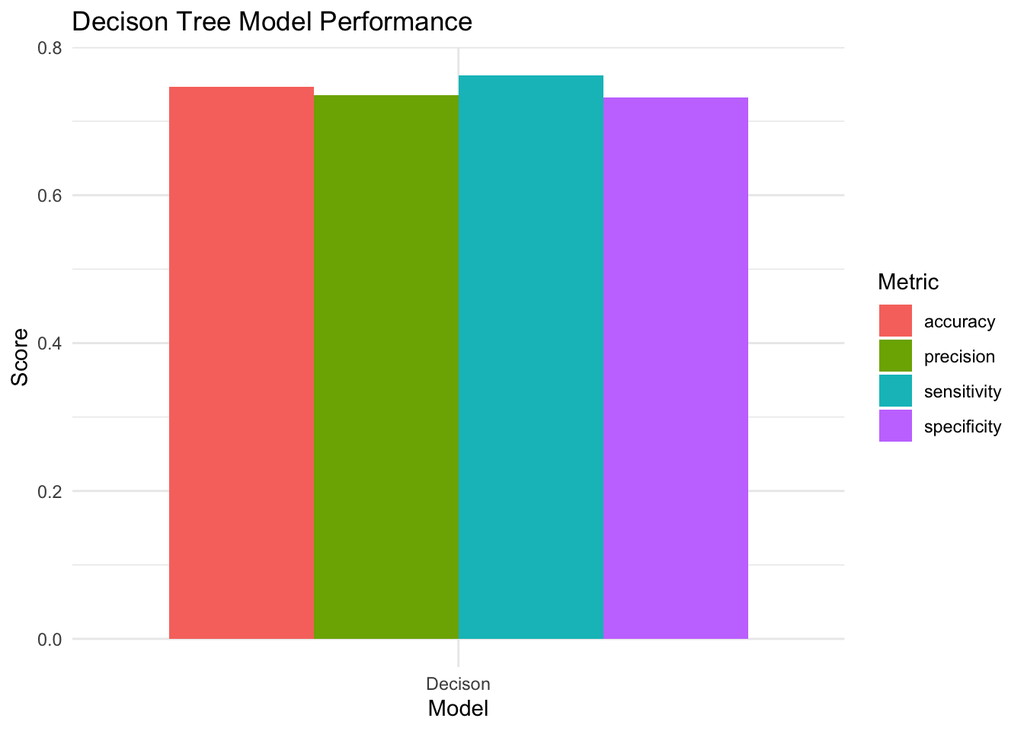

```r
 #Remove empty columns
dt.results <- dt.results %>%
  select(-contains("estimator"),-contains("metric"))
# Plot
dt.results %>%
  pivot_longer(cols = -Model) %>%
  ggplot(aes(x = Model, y = value, fill = name)) +
  geom_bar(stat = "identity", position = "dodge") +
  labs(title = "Decison Tree Model Performance",
       y = "Score", fill = "Metric") +
  theme_minimal()
```

8. Exploratory Data Analysis (EDA)

```r
 #Summary statistics
summary(merged_data)
```

```
##    Retailer               ID               Date
##  Length:6501528     Min.   :1128299   Min.   :2020-01-01 00:00:00.00
##  Class :character   1st Qu.:1185732   1st Qu.:2021-01-28 00:00:00.00
##  Mode  :character   Median :1185732   Median :2021-05-22 00:00:00.00
##                     Mean   :1176153   Mean   :2021-05-01 22:00:49.80
##                     3rd Qu.:1189833   3rd Qu.:2021-09-15 00:00:00.00
##                     Max.   :1197831   Max.   :2021-12-31 00:00:00.00
##     Region             State               City              Gender
##  Length:6501528     Length:6501528     Length:6501528     Length:6501528
##  Class :character   Class :character   Class :character   Class :character
##  Mode  :character   Mode  :character   Mode  :character   Mode  :character
##
##
##
##    Category          PricePerUnit      UnitsSold        TotalSales
##  Length:6501528     Min.   :  7.00   Min.   :   0.0   Min.   :     0
##  Class :character   1st Qu.: 35.00   1st Qu.: 122.0   1st Qu.:  4860
##  Mode  :character   Median : 45.00   Median : 200.0   Median : 10556
##                     Mean   : 44.77   Mean   : 282.1   Mean   :100424
##                     3rd Qu.: 55.00   3rd Qu.: 375.0   3rd Qu.:157500
##                     Max.   :110.00   Max.   :1275.0   Max.   :825000
##      Profit           Margin       SalesMethod            Outcome
##  Min.   :     0   Min.   :0.1000   Length:6501528     In-store:3214573
##  1st Qu.:  2176   1st Qu.:0.3500   Class :character   Outlet  :3286955
##  Median :  4748   Median :0.4200   Mode  :character
##  Mean   : 37295   Mean   :0.4265
##  3rd Qu.: 56000   3rd Qu.:0.5000
##  Max.   :390000   Max.   :0.8000
##      city            city_ascii          state_id         county_fips
##  Length:6501528     Length:6501528     Length:6501528     Length:6501528
##  Class :character   Class :character   Class :character   Class :character
##  Mode  :character   Mode  :character   Mode  :character   Mode  :character
##
##
##
##  county_name             lat             lng            population
##  Length:6501528     Min.   :19.04   Min.   :-176.63   Min.   :       0
##  Class :character   1st Qu.:33.74   1st Qu.:-100.60   1st Qu.:     307
##  Mode  :character   Median :38.22   Median : -91.87   Median :    1121
##                     Mean   :37.60   Mean   : -94.27   Mean   :   16095
##                     3rd Qu.:41.13   3rd Qu.: -81.91   3rd Qu.:    4566
##                     Max.   :71.27   Max.   : -67.02   Max.   :18908608
##     density           source           military       incorporated
##  Min.   :    0.0   Length:6501528     Mode :logical   Mode :logical
##  1st Qu.:   89.9   Class :character   FALSE:6479064   FALSE:2416752
##  Median :  253.1   Mode  :character   TRUE :22464     TRUE :4084776
##  Mean   :  507.5
##  3rd Qu.:  586.5
##  Max.   :28653.9
##    timezone            ranking          zips                 id
##  Length:6501528     Min.   :1.000   Length:6501528     Min.   :1.84e+09
##  Class :character   1st Qu.:3.000   Class :character   1st Qu.:1.84e+09
##  Mode  :character   Median :3.000   Mode  :character   Median :1.84e+09
##                     Mean   :2.979                      Mean   :1.84e+09
##                     3rd Qu.:3.000                      3rd Qu.:1.84e+09
##                     Max.   :5.000                      Max.   :1.84e+09
```

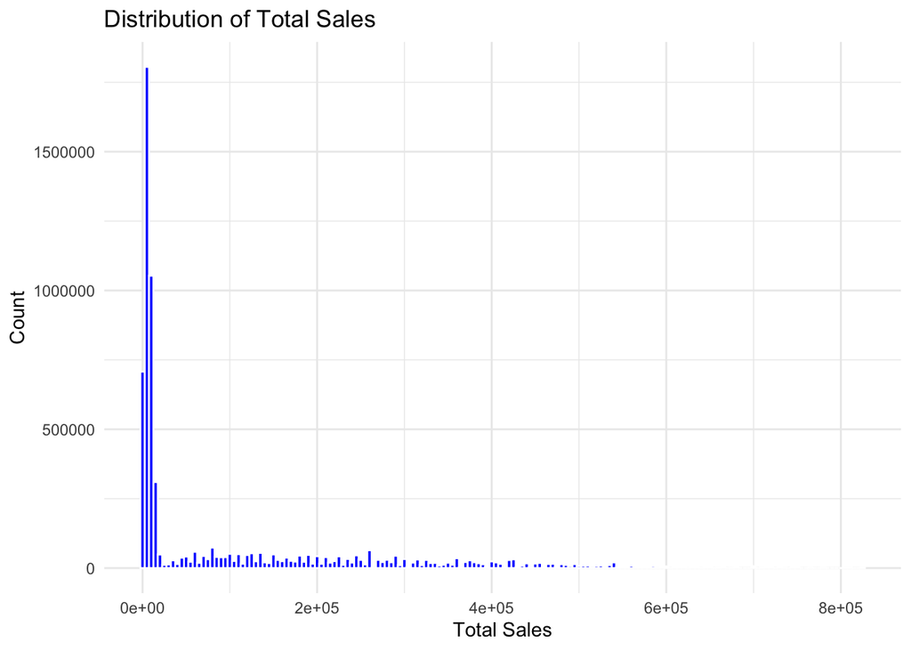

```r
 #Distribution plots of key variables
ggplot(merged_data, aes(x = TotalSales)) +
  geom_histogram(binwidth = 5000, fill = "blue", color = "white") +
  theme_minimal() +
  labs(title = "Distribution of Total Sales", x = "Total Sales", y = "Count")
```

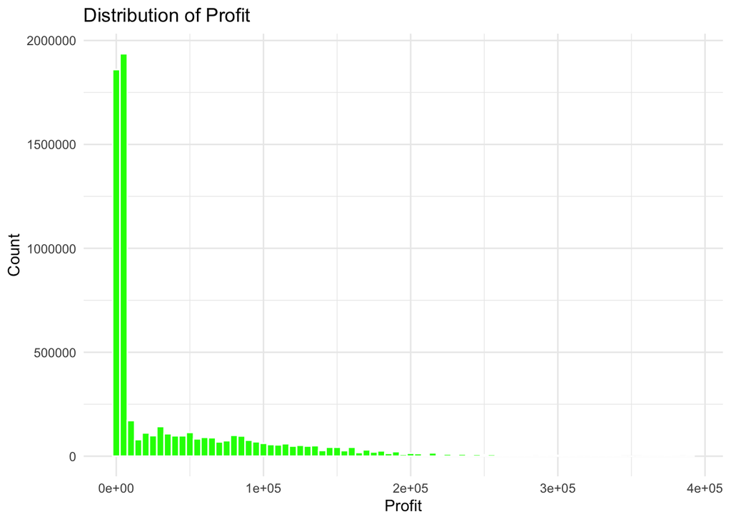

```r
ggplot(merged_data, aes(x = Profit)) +
  geom_histogram(binwidth = 5000, fill = "green", color = "white") +
  theme_minimal() +
  labs(title = "Distribution of Profit", x = "Profit", y = "Count")
```

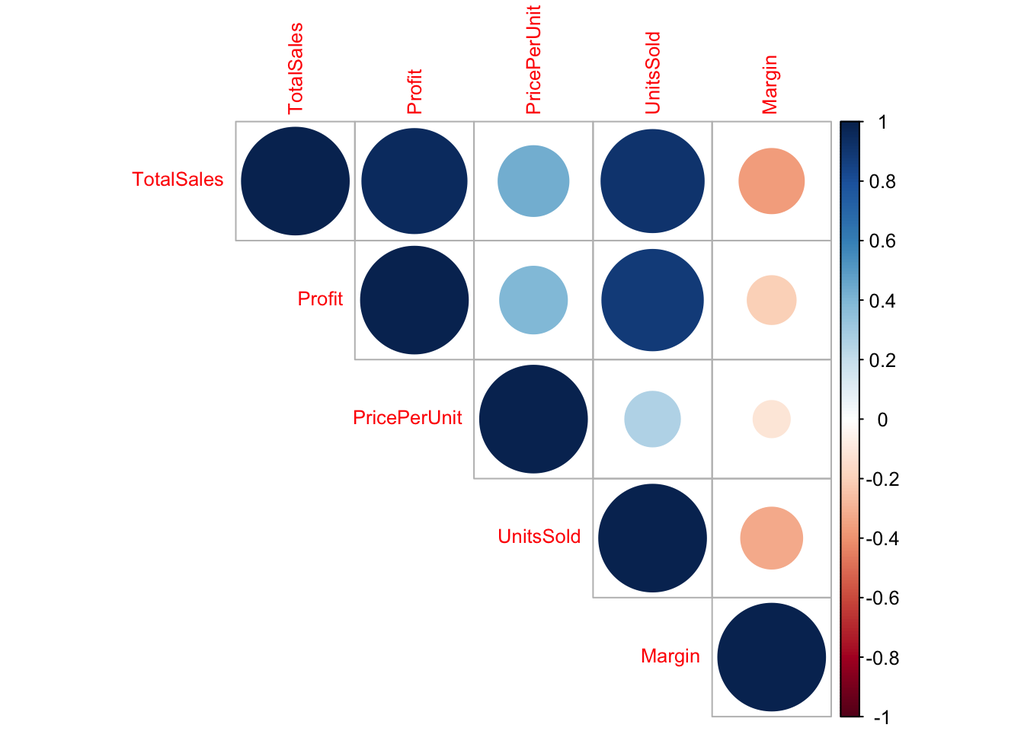

```r
 #Correlation matrix
corr_matrix <- merged_data %>%
  select(TotalSales, Profit, PricePerUnit, UnitsSold, Margin) %>%
  cor()

corrplot::corrplot(corr_matrix, method = "circle", type = "upper", tl.cex = 0.8)
```

Regional Analysis

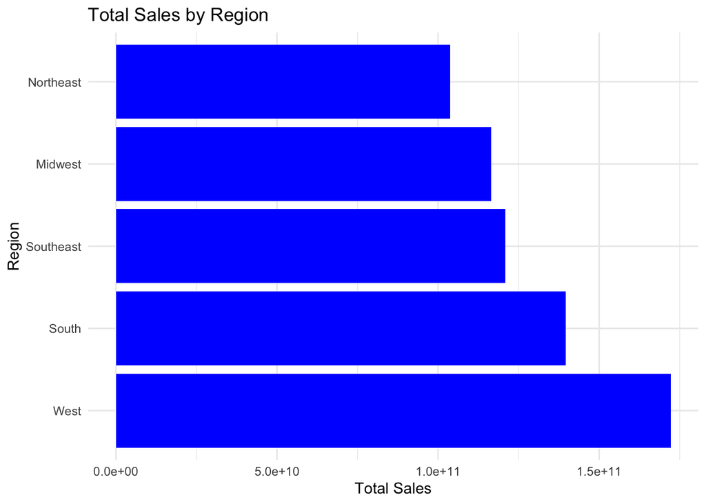

```r
 #Sales and profitability by region
sales_by_region <- merged_data %>%
  group_by(Region) %>%
  summarize(total_sales = sum(TotalSales), total_profit = sum(Profit))

ggplot(sales_by_region, aes(x = reorder(Region, -total_sales), y = total_sales)) +
  geom_bar(stat = "identity", fill = "blue") +
  theme_minimal() +
  coord_flip() +
  labs(title = "Total Sales by Region", x = "Region", y = "Total Sales")
```

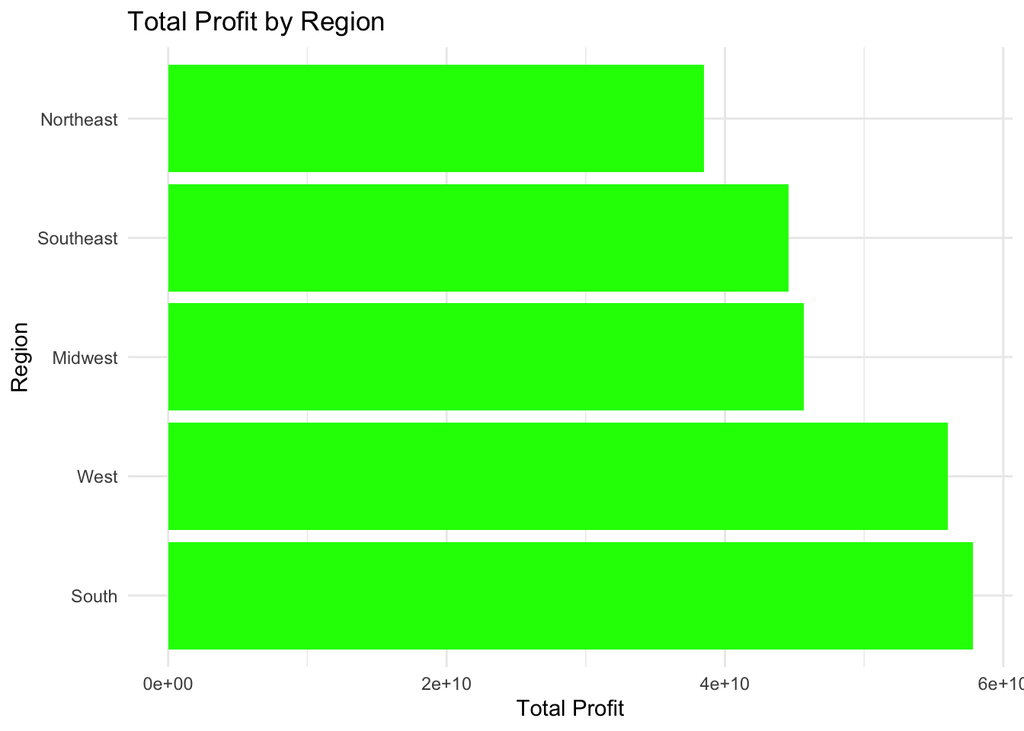

```r
ggplot(sales_by_region, aes(x = reorder(Region, -total_profit), y = total_profit)) +
  geom_bar(stat = "identity", fill = "green") +
  theme_minimal() +
  coord_flip() +
  labs(title = "Total Profit by Region", x = "Region", y = "Total Profit")
```

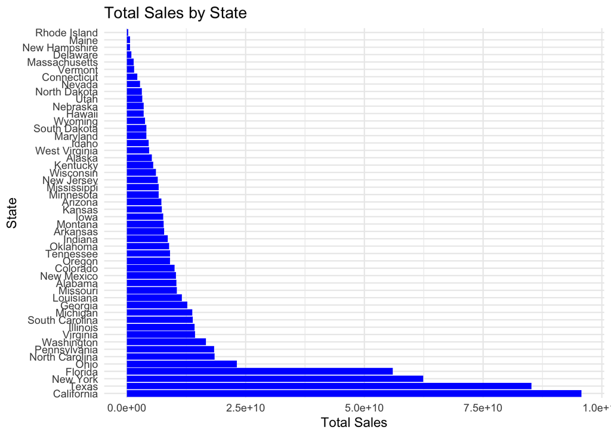

```r
 #Sales distribution across different states
sales_by_state <- merged_data %>%
  group_by(State) %>%
  summarize(total_sales = sum(TotalSales))

ggplot(sales_by_state, aes(x = reorder(State, -total_sales), y = total_sales)) +
  geom_bar(stat = "identity", fill = "blue") +
  theme_minimal() +
  coord_flip() +
  labs(title = "Total Sales by State", x = "State", y = "Total Sales")
```

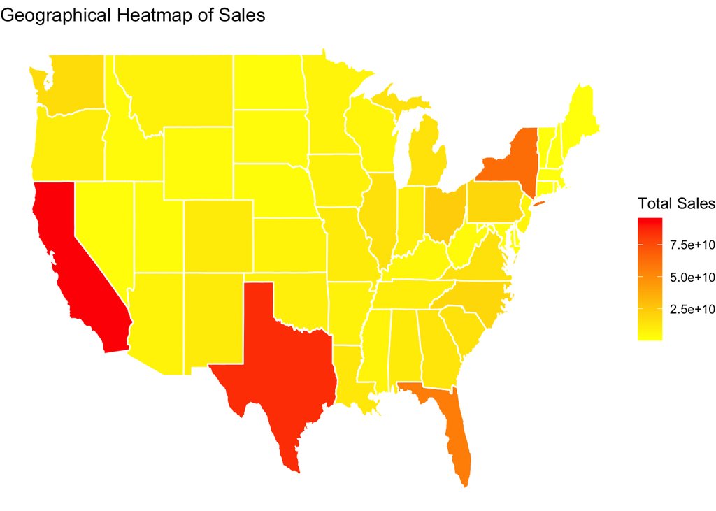

```r
 #Geographical heatmap of sales
us_states <- map_data("state")
merged_data$region <- tolower(merged_data$State)

sales_heatmap <- merged_data %>%
  group_by(region) %>%
  summarize(total_sales = sum(TotalSales))

ggplot(sales_heatmap, aes(map_id = region, fill = total_sales)) +
  geom_map(map = us_states, color = "white") +
  expand_limits(x = us_states$long, y = us_states$lat) +
  theme_void() +
  scale_fill_continuous(low = "yellow", high = "red") +
  labs(title = "Geographical Heatmap of Sales", fill = "Total Sales")
```

Product Category Analysis

```r
 #Sales and profitability by product category
sales_by_category <- merged_data %>%
  group_by(Category) %>%
  summarize(total_sales = sum(TotalSales), total_profit = sum(Profit))
```

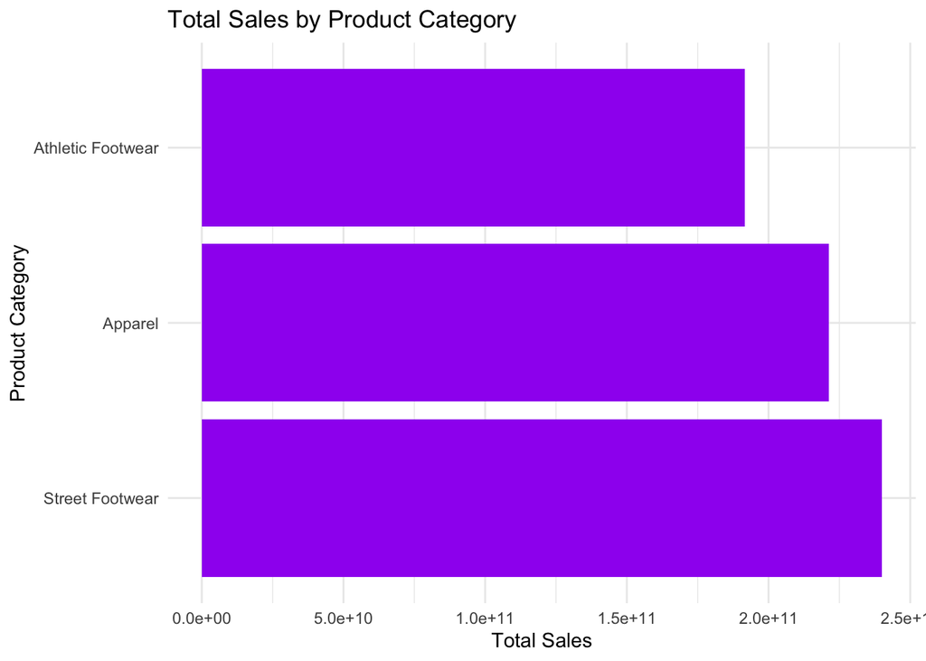

```r
ggplot(sales_by_category, aes(x = reorder(Category, -total_sales), y = total_sales)) +
  geom_bar(stat = "identity", fill = "purple") +
  theme_minimal() +
  coord_flip() +
  labs(title = "Total Sales by Product Category", x = "Product Category", y = "Total Sales")
```

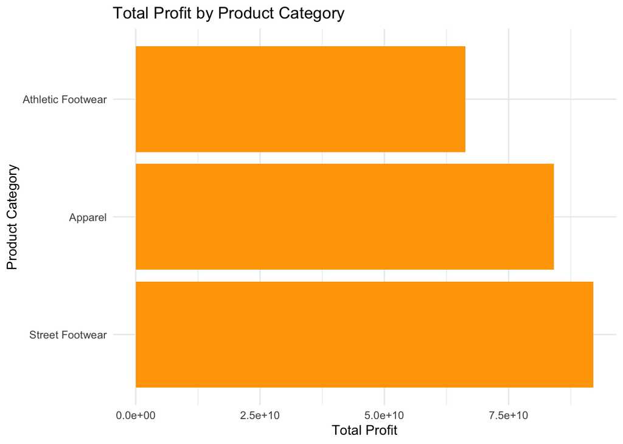

```r
ggplot(sales_by_category, aes(x = reorder(Category, -total_profit), y = total_profit)) +
  geom_bar(stat = "identity", fill = "orange") +
  theme_minimal() +
  coord_flip() +
  labs(title = "Total Profit by Product Category", x = "Product Category", y = "Total Profit")
```

```r
 #Comparison of product categories across regions
category_region <- merged_data %>%
  group_by(Region, Category) %>%
summarize(total_sales = sum(TotalSales))
```

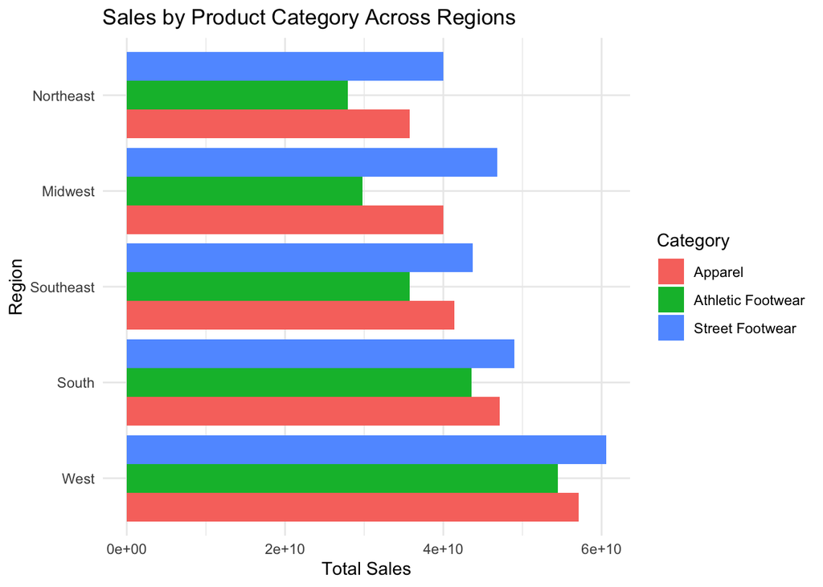

```r
ggplot(category_region, aes(x = reorder(Region, -total_sales), y = total_sales, fill = Category)) +
  geom_bar(stat = "identity", position = "dodge") +
  theme_minimal() +
  coord_flip() +
  labs(title = "Sales by Product Category Across Regions", x = "Region", y = "Total Sales")
```

Line plot for Total Sales over time

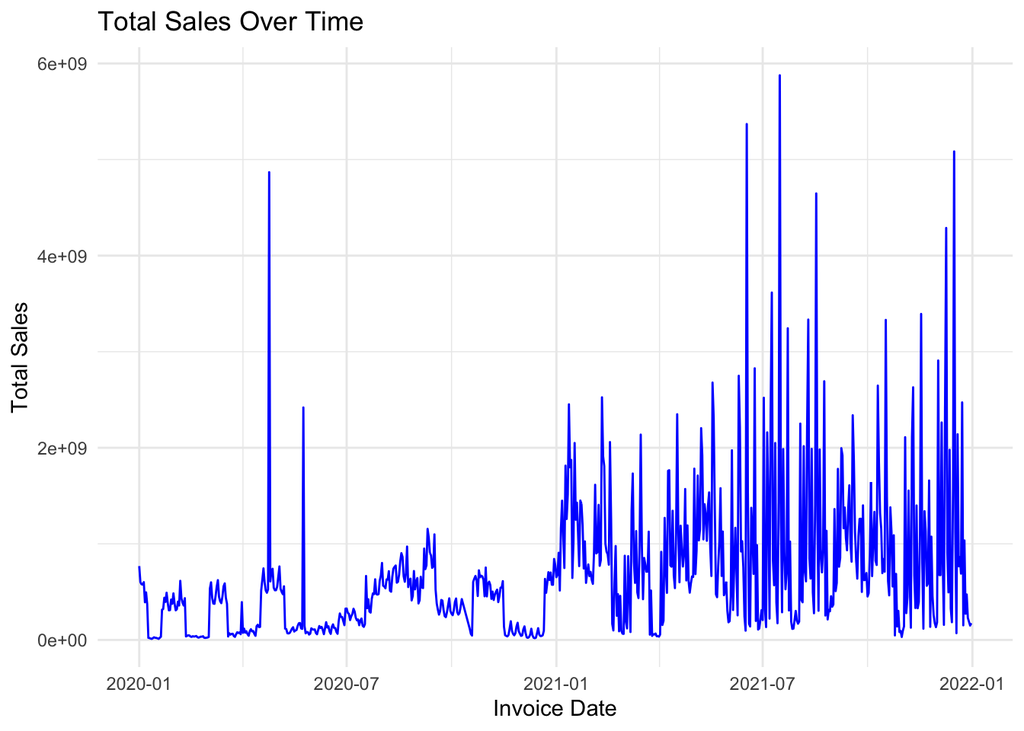

```r
 #Aggregate data to get total sales per date
daily_sales <- train_data %>%
  group_by(Date) %>%
  summarize(Total_Sales = sum(TotalSales))
 #Line plot for Total Sales over time
ggplot(daily_sales, aes(x = Date, y = Total_Sales)) +
  geom_line(color = "blue") +
  labs(title = "Total Sales Over Time", x = "Invoice Date", y = "Total Sales") +
  theme_minimal()
```

Sales Method Analysis

```r
# Effectiveness of different sales methods
sales_by_method <- merged_data %>%
  group_by(Outcome) %>%
  summarize(total_sales = sum(TotalSales), total_profit = sum(Profit))
```

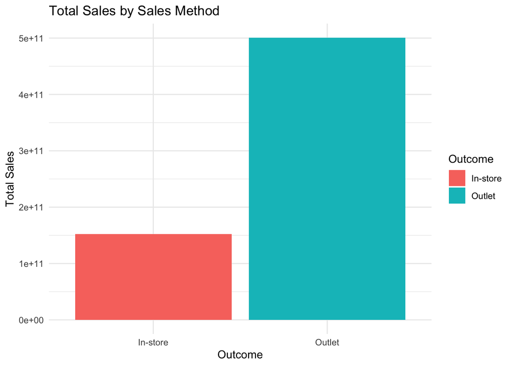

```r
ggplot(sales_by_method, aes(x = Outcome, y = total_sales, fill = Outcome)) +
  geom_bar(stat = "identity") +
  theme_minimal() +
  labs(title = "Total Sales by Sales Method", x = "Outcome", y = "Total Sales")
```

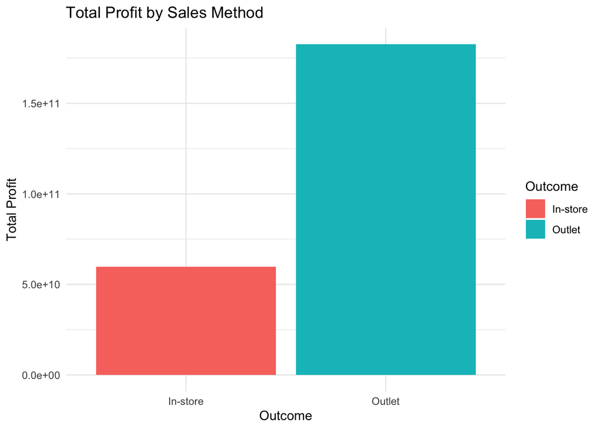

```r
ggplot(sales_by_method, aes(x = Outcome, y = total_profit, fill = Outcome)) +
  geom_bar(stat = "identity") +
  theme_minimal() +
  labs(title = "Total Profit by Sales Method", x = "Outcome", y = "Total Profit")
```

Key Drivers Identification

Regression Analysis

```r
# Linear regression model to identify key drivers of sales
sales_model <- lm(TotalSales ~ PricePerUnit + UnitsSold + Profit + Margin + Region + Category + SalesMethod, data = merged_data)
summary(sales_model)
```

```
##
## Call:
## lm(formula = TotalSales ~ PricePerUnit + UnitsSold + Profit +
##     Margin + Region + Category + SalesMethod, data = merged_data)
##
## Residuals:
##     Min      1Q  Median      3Q     Max
## -136836  -15571   -1511   14311  245665
##
## Coefficients:
##                             Estimate Std. Error  t value Pr(>|t|)
## (Intercept)                3.531e+04  9.672e+01   365.03   <2e-16 ***
## PricePerUnit               9.390e+02  1.137e+00   825.64   <2e-16 ***
## UnitsSold                  2.043e+02  1.368e-01  1493.22   <2e-16 ***
## Profit                     1.619e+00  5.470e-04  2959.73   <2e-16 ***
## Margin                    -1.971e+05  1.561e+02 -1263.28   <2e-16 ***
## RegionNortheast           -6.206e+03  4.191e+01  -148.06   <2e-16 ***
## RegionSouth               -7.422e+03  4.043e+01  -183.57   <2e-16 ***
## RegionSoutheast           -1.081e+04  4.503e+01  -240.05   <2e-16 ***
## RegionWest                -6.089e+03  4.134e+01  -147.29   <2e-16 ***
## CategoryAthletic Footwear  2.100e+03  3.250e+01    64.63   <2e-16 ***
## CategoryStreet Footwear   -5.002e+03  3.345e+01  -149.52   <2e-16 ***
## SalesMethodOnline         -1.832e+03  4.430e+01   -41.34   <2e-16 ***
## SalesMethodOutlet         -9.343e+03  4.294e+01  -217.60   <2e-16 ***
## ---
## Signif. codes:  0 '***' 0.001 '**' 0.01 '*' 0.05 '.' 0.1 ' ' 1
##
## Residual standard error: 32340 on 6501515 degrees of freedom
## Multiple R-squared:  0.9548, Adjusted R-squared:  0.9548
## F-statistic: 1.144e+07 on 12 and 6501515 DF,  p-value: < 2.2e-16
```

```r
# Extract feature importance from the model
coefficients <- summary(sales_model)$coefficients
coefficients
```

```
##                                Estimate   Std. Error     t value Pr(>|t|)
## (Intercept)                 35306.96549 9.672250e+01   365.03365        0
## PricePerUnit                  939.01832 1.137325e+00   825.63749        0
## UnitsSold                     204.32127 1.368329e-01  1493.21780        0
## Profit                          1.61894 5.469893e-04  2959.72871        0
## Margin                    -197139.99628 1.560545e+02 -1263.27654        0
## RegionNortheast             -6205.96501 4.191411e+01  -148.06387        0
## RegionSouth                 -7422.47226 4.043283e+01  -183.57538        0
## RegionSoutheast            -10808.09158 4.502515e+01  -240.04566        0
## RegionWest                  -6089.07378 4.133998e+01  -147.29261        0
## CategoryAthletic Footwear    2100.48977 3.250242e+01    64.62563        0
## CategoryStreet Footwear     -5001.64701 3.345076e+01  -149.52267        0
## SalesMethodOnline           -1831.65863 4.430289e+01   -41.34400        0
## SalesMethodOutlet           -9343.49242 4.293825e+01  -217.60303        0
```

Feature Importance from Decision Tree

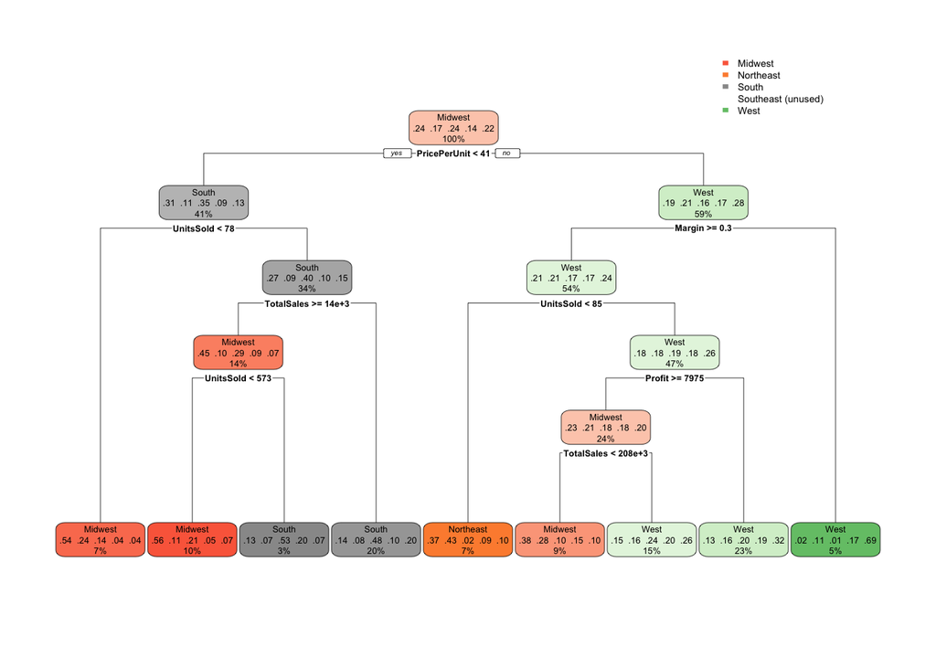

```r
# Train Decision Tree Model
t_model <- rpart(Region ~ PricePerUnit + UnitsSold + Profit + Margin + TotalSales + Category + Outcome, data = merged_data)

# Plot the decision tree
rpart.plot::rpart.plot(t_model)
```

```r
 #Feature importance
importance <- varImp(t_model)
importance
```

|  | Overall |
| --- | --- |
| Margin | 302005.4 |
| Outcome | 137016.3 |
| PricePerUnit | 280222.3 |
| Profit | 380240.0 |
| TotalSales | 428152.9 |
| UnitsSold | 422695.8 |
| Category | 0.0 |

So far we can Deduce that the region with the highest number of sales is not the region with the highest profit . And in some regions, some Adidas stores do better than others. Across the Board, we can also deduce that to drive profit margins and number of sales, an Outlet store should be the Sales method of Choice.

To determine the optimal location for a new Adidas outlet, we’ll consider several factors, including:

Geographical coordinates (latitude and longitude) Profit and total sales data Distance to existing high-performing stores

We’ll follow these steps:

*Identify high-performing stores:* We’ll consider stores with profits and total sales above a certain threshold as high-performing. *Calculate distances:* We’ll calculate distances between potential new locations and existing high-performing stores to ensure the new location is not too close to a high-performing store. *Determine optimal location:* We’ll identify locations with high potential sales and profit but without nearby high-performing stores.

```r
# Assume high-performing stores are defined as those with total sales and profit above certain thresholds
high_performance_threshold_sales <- quantile(merged_data$TotalSales, 0.75)
high_performance_threshold_profit <- quantile(merged_data$Profit, 0.75)

# Filter out high-performing stores
filtered_data <- merged_data %>%
  filter(TotalSales <= high_performance_threshold_sales,
         Profit <= high_performance_threshold_profit)

 #Select relevant columns for clustering
clustering_data <- filtered_data %>%
  select(lat, lng, TotalSales, Profit)

# Normalize the data for clustering
clustering_data_norm <- clustering_data %>%
  mutate(across(c(TotalSales, Profit), scale))

# Perform K-means clustering to find potential clusters (choose k based on the elbow method or domain knowledge)
k <- 5  #Number of clusters (this can be adjusted based on the dataset and desired granularity)
kmeans_result <- kmeans(clustering_data_norm, centers = k, nstart = 25)

 #Add cluster information to the data
filtered_data$cluster <- kmeans_result$cluster

 #Calculate cluster centers
cluster_centers <- kmeans_result$centers %>%
  as.data.frame() %>%
  mutate(cluster = 1:k)
```

```r
# Calculate mean and standard deviation for normalization
total_sales_mean <- mean(clustering_data$TotalSales, na.rm = TRUE)
total_sales_sd <- sd(clustering_data$TotalSales, na.rm = TRUE)
profit_mean <- mean(clustering_data$Profit, na.rm = TRUE)
profit_sd <- sd(clustering_data$Profit, na.rm = TRUE)

# Denormalize the cluster centers
cluster_centers <- cluster_centers %>%
  mutate(
    TotalSales = TotalSales * total_sales_sd + total_sales_mean,
    Profit = Profit * profit_sd + profit_mean
  )

# Identify the best cluster centers (potential locations for new stores)
best_cluster_centers <- cluster_centers %>%
  arrange(desc(TotalSales), desc(Profit))

# Filter out cluster centers that are too close to existing high-performing stores
high_performing_stores <- merged_data %>%
  filter(TotalSales > high_performance_threshold_sales,
         Profit > high_performance_threshold_profit)

 #Minimum distance threshold (in kilometers) from high-performing stores
distance_threshold <- 10

# Rename columns to avoid duplication
best_cluster_centers <- best_cluster_centers %>%
  rename(lat_cluster = lat, lng_cluster = lng)

high_performing_stores <- high_performing_stores %>%
  rename(lat_store = lat, lng_store = lng)

 #Use tidyr::crossing to create combinations of cluster centers and high-performing stores
distances <- crossing(
  best_cluster_centers %>% select(lat_cluster, lng_cluster),
  high_performing_stores %>% select(lat_store, lng_store)
) %>%
  mutate(
    distance = distHaversine(
      cbind(lng_cluster, lat_cluster),
      cbind(lng_store, lat_store)
    ) / 1000
  )

 #Summarize the minimum distance for each cluster center
min_distances <- distances %>%
  group_by(lat_cluster, lng_cluster) %>%
  summarize(min_distance = min(distance))
 #Join the minimum distances back to the cluster centers
top_suitable_locations <- best_cluster_centers %>%
  inner_join(min_distances, by = c("lat_cluster" = "lat_cluster", "lng_cluster" = "lng_cluster")) %>%
  filter(min_distance > distance_threshold)

 #Display the top suitable locations for new store locations
top_suitable_locations
```

| lat_cluster | lng_cluster | TotalSales | Profit | cluster | min_distance |
| --- | --- | --- | --- | --- | --- |
| 50.15828 | -153.4980 | 30447.61 | 8571.658 | 3 | 742.3278 |
| 38.97383 | -117.7491 | 14414.40 | 5542.708 | 4 | 20.2109 |

```r
 #Function to find the nearest city given a lat and lng
find_nearest_city <- function(lat, lng, data) {
   #Calculate the Euclidean distance between the given point and all points in the dataset
  distances <- sqrt((data$lat - lat)^2 + (data$lng - lng)^2)
   #Find the index of the minimum distance
  nearest_city_index <- which.min(distances)
   #Return the nearest city
  nearest_city <- data[nearest_city_index, ]
  return(nearest_city)
}


nearest_city <- find_nearest_city(top_suitable_locations$lat, top_suitable_locations$lng, merged_data)
# Filter for apparel category and top suitable locations
apparel_data <- merged_data[merged_data$Category == "Apparel", ]

 #Print a summary of the filtered apparel data
summary(apparel_data)
```

```
##    Retailer               ID               Date
##  Length:2166470     Min.   :1128299   Min.   :2020-01-01 00:00:00.00
##  Class :character   1st Qu.:1185732   1st Qu.:2021-01-28 00:00:00.00
##  Mode  :character   Median :1185732   Median :2021-05-23 00:00:00.00
##                     Mean   :1176220   Mean   :2021-05-02 03:17:27.91
##                     3rd Qu.:1189833   3rd Qu.:2021-09-14 00:00:00.00
##                     Max.   :1197831   Max.   :2021-12-31 00:00:00.00
##     Region             State               City              Gender
##  Length:2166470     Length:2166470     Length:2166470     Length:2166470
##  Class :character   Class :character   Class :character   Class :character
##  Mode  :character   Mode  :character   Mode  :character   Mode  :character
##
##
##
##    Category          PricePerUnit      UnitsSold        TotalSales
##  Length:2166470     Min.   : 14.00   Min.   :   6.0   Min.   :   252
##  Class :character   1st Qu.: 40.00   1st Qu.: 105.0   1st Qu.:  4700
##  Mode  :character   Median : 50.00   Median : 179.0   Median : 10872
##                     Mean   : 50.42   Mean   : 255.1   Mean   :102180
##                     3rd Qu.: 60.00   3rd Qu.: 325.0   3rd Qu.:157500
##                     Max.   :110.00   Max.   :1100.0   Max.   :825000
##      Profit           Margin       SalesMethod            Outcome
##  Min.   :   121   Min.   :0.1000   Length:2166470     In-store:1070875
##  1st Qu.:  2138   1st Qu.:0.3500   Class :character   Outlet  :1095595
##  Median :  5173   Median :0.4300   Mode  :character
##  Mean   : 38843   Mean   :0.4342
##  3rd Qu.: 56000   3rd Qu.:0.5100
##  Max.   :371250   Max.   :0.8000
##      city            city_ascii          state_id         county_fips
##  Length:2166470     Length:2166470     Length:2166470     Length:2166470
##  Class :character   Class :character   Class :character   Class :character
##  Mode  :character   Mode  :character   Mode  :character   Mode  :character
##
##
##
##  county_name             lat             lng            population
##  Length:2166470     Min.   :19.04   Min.   :-176.63   Min.   :       0
##  Class :character   1st Qu.:33.73   1st Qu.:-100.58   1st Qu.:     307
##  Mode  :character   Median :38.22   Median : -91.86   Median :    1121
##                     Mean   :37.60   Mean   : -94.25   Mean   :   16100
```

[output cut: 8 more lines]

```
##  Max.   :28653.9
##    timezone            ranking          zips                 id
##  Length:2166470     Min.   :1.000   Length:2166470     Min.   :1.84e+09
##  Class :character   1st Qu.:3.000   Class :character   1st Qu.:1.84e+09
##  Mode  :character   Median :3.000   Mode  :character   Median :1.84e+09
##                     Mean   :2.979                      Mean   :1.84e+09
##                     3rd Qu.:3.000                      3rd Qu.:1.84e+09
##                     Max.   :5.000                      Max.   :1.84e+09
##     region
##  Length:2166470
##  Class :character
##  Mode  :character
##
##
##
```

```r
 #Find the nearest city in the apparel dataset for the given lat and lng
nearest_apparel_city <- find_nearest_city(nearest_city$lat, nearest_city$lng, apparel_data)
```

```r
print(nearest_city$State )
```

```
## [1] "Nevada"
```

```r
print(nearest_city$City)
```

```
## [1] "Las Vegas"
```

To calculate the churn rate and determine the best price per unit for apparel in the top suitable locations, we need to follow these steps:

*Analyze Key Metrics:* We’ll use the price per unit, profit, margin, and total sales to analyze the performance and churn rate.

```r
 #Convert SpatialPointsDataFrame to data.frame if necessary
if (inherits(apparel_data, "SpatialPointsDataFrame")) {
  apparel_data <- as.data.frame(apparel_data)
}

# Ensure 'PricePerUnit' is not a factor
apparel_data$PricePerUnit <- as.numeric(as.character(apparel_data$PricePerUnit))

# Aggregate data by PricePerUnit
price_analysis <- apparel_data %>%
  group_by(PricePerUnit) %>%
  summarize(
    total_sales = sum(TotalSales, na.rm = TRUE),
    total_profit = sum(Profit, na.rm = TRUE),
    avg_margin = mean(Margin, na.rm = TRUE),
    churn_rate = 1 - (sum(UnitsSold, na.rm = TRUE) / n())
  )

# Print the summary of the price analysis
summary(price_analysis)
```

```
##   PricePerUnit     total_sales         total_profit         avg_margin
##  Min.   : 14.00   Min.   :2.044e+06   Min.   :8.526e+05   Min.   :0.2606
##  1st Qu.: 35.25   1st Qu.:2.907e+07   1st Qu.:1.395e+07   1st Qu.:0.4018
##  Median : 56.50   Median :1.173e+08   Median :6.132e+07   Median :0.4551
##  Mean   : 57.23   Mean   :2.574e+09   Mean   :9.785e+08   Mean   :0.4413
##  3rd Qu.: 77.75   3rd Qu.:3.002e+08   3rd Qu.:1.418e+08   3rd Qu.:0.4869
##  Max.   :110.00   Max.   :3.592e+10   Max.   :1.290e+10   Max.   :0.5700
##    churn_rate
##  Min.   :-699.00
##  1st Qu.:-183.28
##  Median :-142.77
##  Mean   :-203.51
##  3rd Qu.:-128.50
##  Max.   : -88.64
```

```r
print(apparel_data$PricePerUnit[1] )
```

```
## [1] 55
```

```r
 #Display the price analysis data
print(price_analysis)
```

```
## # A tibble: 86 × 5
##    PricePerUnit total_sales total_profit avg_margin churn_rate
##           <dbl>       <dbl>        <dbl>      <dbl>      <dbl>
##  1           14     4375756     2413673.      0.536      -95.3
##  2           15    68137500    27255000       0.4       -249
##  3           16     2044464      852637.      0.417     -133.
##  4           17     2680186     1159104.      0.427     -124.
##  5           18    12284550     6130095.      0.494     -112.
##  6           19     4283569     2130859.      0.495      -88.6
##  7           20   402527620   171789010       0.450     -225.
##  8           21     2159871      993780.      0.440     -107.
##  9           22    19541698     9741600.      0.477     -137.
## 10           23    21864950    10535992.      0.482      -92.9
## # ℹ 76 more rows
```

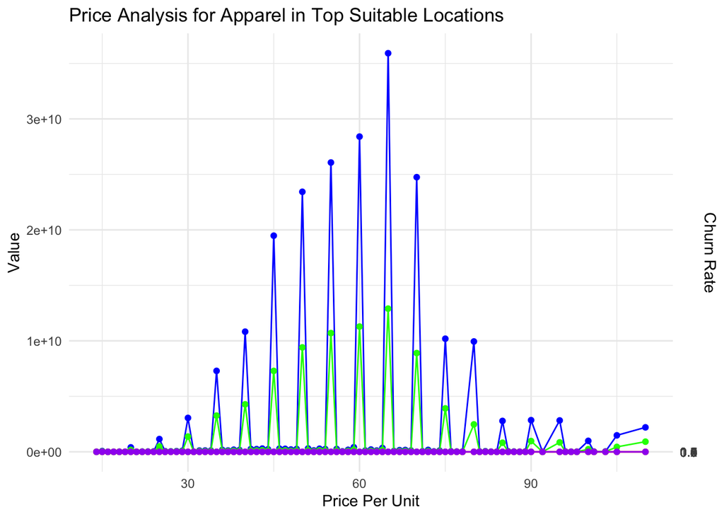

```r
 #Visualize the performance metrics
ggplot(price_analysis) +
  geom_line(aes(x = PricePerUnit, y = total_sales), color = "blue") +
  geom_point(aes(x = PricePerUnit, y = total_sales), color = "blue") +
  geom_line(aes(x = PricePerUnit, y = total_profit), color = "green") +
  geom_point(aes(x = PricePerUnit, y = total_profit), color = "green") +
  geom_line(aes(x = PricePerUnit, y = avg_margin), color = "red") +
  geom_point(aes(x = PricePerUnit, y = avg_margin), color = "red") +
  geom_line(aes(x = PricePerUnit, y = churn_rate), color = "purple") +
  geom_point(aes(x = PricePerUnit, y = churn_rate), color = "purple") +
  labs(title = "Price Analysis for Apparel in Top Suitable Locations",
       x = "Price Per Unit",
       y = "Value",
       color = "Metrics") +
  theme_minimal() +
  scale_y_continuous(sec.axis = sec_axis(~ ., name = "Churn Rate", breaks = seq(0, 1, by = 0.1)))
```

**Conclusions and Recommendations**

- *Key Market Regions:* The analysis of total sales by state and region reveals key market regions where Adidas has high sales. These regions should be targeted for more aggressive marketing campaigns and promotional activities.
- *Geographical Insights:* The geographical distribution of sales indicates potential areas where Adidas can increase its presence. Regions with lower sales could benefit from targeted advertisements and localized promotions.
- *Product Category Performance:* Certain product categories contribute significantly to total sales and profit. These categories should be prioritized in marketing and inventory strategies.
- *Sales Method Effectiveness:* The comparison of sales methods highlights the effectiveness of different sales approaches. Strategies can be tailored based on the performance of each sales method.
- *Key Drivers of Sales:* Regression analysis , churn rate and feature importance from decision tree models help identify key drivers of sales. These insights can be used to optimize pricing, inventory management, and promotional strategies.

By leveraging these insights, Adidas can make data-driven decisions to boost sales and optimize business processes, ultimately enhancing profitability and customer satisfaction.